# PSE-823: Advanced Process Dynamics and Control

## Lecture 15 -- Dead-Time Compensation and Model Predictive Control

### (Cecil, Ch. 8, Sec. 8.2-8.3)

Date: __________

## Agenda

**Part A** -- Dead-time compensation: the paper machine (Sec. 8.2)

**Part B** -- Step-response models and the dynamic matrix (Sec. 8.3)

**Part C** -- MPC on the jacketed reactor: horizons, move suppression, constraints

**Part D** -- The model inside MPC, identified from data

### Setup (run once)

- The standard imports, plus tools for delays, matrices, optimization and regression

```python
import numpy as np
import matplotlib.pyplot as plt
import sympy as sp
import control as ct
from scipy.integrate import solve_ivp
from scipy.optimize import curve_fit
plt.rcParams.update({"font.size": 15})
from collections import deque
from scipy.optimize import brentq
from scipy.linalg import toeplitz
from gekko import GEKKO
from sklearn.linear_model import LinearRegression, RidgeCV
```

## Part A

### Dead-Time Compensation

(Cecil, Ch. 8, Sec. 8.2)

### Introduce -- a process dominated by dead time (Fig. 8.8)

- Paper machine: basis weight measured at the reel, about a minute after the stock valve acts.
- Model: dead time $\theta = 1.2$ min, time constant $\tau = 0.17$ min, gain $K = 0.67$ %/%.
- Disturbance: actual consistency 2% -> 2.2% (+10% basis weight).
- PID must wait **two dead times** before seeing any correction.
- Minutes matter: at 1600 ft/min, 8 min is over 2 miles of paper.

### Derive 1/2 -- PID limits (Fig. 8.9)

Crossover: $\tan^{-1}(0.17\omega) + 1.2\omega = \pi$ (Lecture 8):

Cecil: $K_u = 1.6$ %/%, $P_u = 2.7$ min. Quarter decay: $K_C = K_u/2 = 0.8$, $T_I = P_u = 2.7$ min. Lambda tuning with $\tau_{CL} = \theta$: $K_C = \frac{\tau}{\tau_{CL} + \theta}\frac1K = 0.11$, $T_I = \tau = 0.17$ min.

### Derive 2/2 -- the Smith predictor (Figs. 8.14-8.15)

Run a model beside the process; feed the controller a prediction:

$$\tilde W(t + \theta) = W(t) + [\hat W(t + \theta) - \hat W(t)]$$

$\hat W(t + \theta)$: model output before its dead time; $\hat W(t)$: after it. The bracket is the effect of moves made in the last dead time, not yet measured. With a perfect model the controller sees only the lag: tune it hard.

### Code 1/3 -- ultimate gain and period

- Mirrors Derive 1/2 with `brentq` (Lecture 8)

```python
K, tau, theta = 0.67, 0.17, 1.2
w = brentq(lambda w: np.arctan(tau*w) + theta*w - np.pi, 0.1, 10)
Ku = np.sqrt(1 + (tau * w)**2) / K
print(f"w_co = {w:.3f} rad/min, Ku = {Ku:.2f} %/%, "
      f"Pu = {2*np.pi/w:.2f} min")
print(f"Lambda: Kc = {tau / (2*theta) / K:.3f}, TI = {tau} min")
```

```
w_co = 2.307 rad/min, Ku = 1.60 %/%, Pu = 2.72 min
Lambda: Kc = 0.106, TI = 0.17 min
```

**Code walkthrough.** The crossover equation is solved as in Lecture 8; Ku = 1/AR there, with AR = K/sqrt(1 + (tau w)^2). Prints w_co = 2.307 rad/min, Ku = 1.60 %/% and Pu = 2.72 min (Cecil: 1.6 and 2.7). Lambda tuning gives Kc = 0.17/(2.4)/0.67 = 0.106 (Cecil rounds to 0.11) and TI = 0.17 min.

### Code 2/3 -- the loop, with and without the predictor

- Dead times as queues (Lecture 8); PI with set point 0
- `smith=True` adds the bracket of Derive 2/2 to the PV

```python
def paper(Kc, TI, smith=False, th_m=1.2, dt=0.005, t_end=12):
    sheet = deque([0.0] * round(theta / dt))    # true dead time
    model = deque([0.0] * round(th_m / dt))     # model dead time
    x = xm = I = 0.0; W = []
    for _ in range(int(t_end / dt)):
        pv = sheet[0] + (xm - model[0] if smith else 0)   # Fig. 8.15
        I += -pv * dt; u = Kc * (-pv + I / TI)            # PI
        x += dt * (K * (u + 15) - x) / tau      # 15% load from t = 0
        xm += dt * (K * u - xm) / tau           # model, no load
        sheet.append(x); model.append(xm); model.popleft()
        W.append(sheet.popleft())
    return np.array(W)
```

**Code walkthrough.** `sheet` carries the true weight through the machine; `model` carries the model's. Each step: the PV is the measurement `sheet[0]`, plus (Smith) the model output before its delay minus after it. The PI controller acts on -PV. The process lag gets the controller output plus the load: 15% of valve equivalent, i.e. +10% weight (0.67 x 15) if uncontrolled. The model gets the controller output only -- it cannot know the consistency changed. `W` records the measured weight.

### Code 3/3 -- three controllers (Fig. 8.9 and beyond)

- IAE over 12 min in the legend

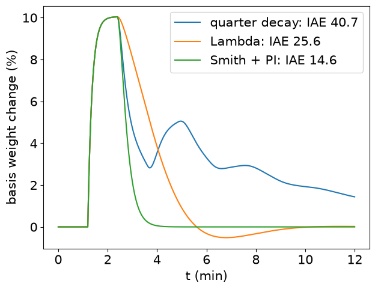

```python
t = np.arange(int(12 / 0.005)) * 0.005
fig, ax = plt.subplots(figsize=(7, 5.25))
for name, args in [("quarter decay", (0.8, 2.7)),
                   ("Lambda", (0.11, 0.17)),
                   ("Smith + PI", (1.0, 0.17, True))]:
    W = paper(*args)
    ax.plot(t, W, label=f"{name}: IAE {np.trapezoid(abs(W), t):.1f}")
ax.set(xlabel="t (min)", ylabel="basis weight change (%)"); ax.legend()
plt.show()
```

### Build on it -- the model's dead time is 20% too long

- Machine speed changed; the predictor was not updated

```python
W = paper(1.0, 0.17, smith=True, th_m=1.44)
print(f"IAE = {np.trapezoid(abs(W), t):.2f}, "
      f"last time |W| > 0.5: {t[abs(W) > 0.5].max():.2f} min")
```

[output not shown]

**Code walkthrough.** Same controller, model dead time 1.44 min against the true 1.2. IAE rises from 14.6 to 18.75 and the response is outside +/-0.5% until 8.35 min, worse than Lambda tuning's line-out. The predictor's benefit depends on an accurate dead time (Cecil: on a paper machine it varies with machine speed, so it must be computed from the speed).

### Your Turn (6 min)

1. By hand: Lambda tuning with $\tau_{CL} = 2\theta$ instead of $\theta$. New $K_C$?
2. Read the code: what does this print?

```
q = deque([0.0, 0.0, 0.0]); out = []
for x in [1.0, 2.0, 3.0, 4.0]:
    q.append(x); out.append(q.popleft())
print(out)
```

(1) Kc = 0.17/(2.4 + 1.2)/0.67 = 0.070 %/%: slower still. (2) [0.0, 0.0, 0.0, 1.0]: each value comes out three steps later -- a dead time of three samples.

### Check -- cold-call

The operators beat the PID by: read the scan, turn the stock valve by the "calibrated" amount, then **wait a dead time**. Which part of the Smith predictor does the waiting correspond to?

The bracket W-hat(t + theta) - W-hat(t): the memory of moves already made but not yet seen. It stops the controller from piling on more correction while the first one is still travelling down the machine.

## Part B

### Step-Response Models and the Dynamic Matrix

(Cecil, Ch. 8, Sec. 8.3)

### Introduce -- a model as a list of numbers (Table 8.3)

- Reactor with a once-through jacket (Fig. 8.21): cooling water $108.8 \to 88.8$ lb/min; temperature $150 \to 154.5$ F.
- Step response per unit input: $s(k) = c(k)/(-20)$, every $\Delta t = 15$ min; flat after $N = 13$ points.
- Impulse response $g(k) = s(k) - s(k-1)$.
- **Free-form**: no structure assumed. Linear, so superposition holds.

### Derive 1/2 -- prediction by superposition

Write any input as steps $\Delta m(j)$; add their responses:

$$c(k) = \sum_j s(k - j)\,\Delta m(j)$$

Pulse of +40 lb/min for 30 min: $\Delta m(0) = +40$, $\Delta m(2) = -40$ (Table 8.4).

### Derive 2/2 -- the dynamic matrix and QDMC

Effect of $L$ future moves on $R$ future outputs:

$$\mathbf x = A\,\Delta\mathbf m,\quad A = \begin{bmatrix} s(1) & 0\\ s(2) & s(1)\\ \vdots & \vdots\\ s(R) & s(R-1)\end{bmatrix}$$

Choose $\Delta\mathbf m$ to cancel the predicted errors $\hat{\mathbf e}$ in least squares: $\Delta\mathbf m = (A^TA)^{-1}A^T\hat{\mathbf e}$. Implement only the first move; repeat next sample.

### Code 1/3 -- Table 8.3

- From the step test to $s(k)$ and $g(k)$

```python
c_test = np.array([0, 1.0, 1.9, 2.5, 3.0, 3.4, 3.7, 3.9, 4.1, 4.2,
                   4.3, 4.4, 4.4, 4.5])           # F, every 15 min
s = c_test / -20                                  # F per (lb/min)
g = np.diff(s)
print("s:", s.round(3)); print("g:", g.round(3))
```

```
s: [-0.    -0.05  -0.095 -0.125 -0.15  -0.17  -0.185 -0.195 -0.205 -0.21
 -0.215 -0.22  -0.22  -0.225]
g: [-0.05  -0.045 -0.03  -0.025 -0.02  -0.015 -0.01  -0.01  -0.005 -0.005
 -0.005  0.    -0.005]
```

**Code walkthrough.** The test changed the flow by -20 lb/min, so dividing by -20 gives the response to +1 lb/min. Prints s = 0, -0.05, -0.095, ..., -0.225 and g = -0.05, -0.045, -0.03, ..., with s(11) = s(12) (g(12) = 0): the 0.1 F resolution of the thermometer shows up as "quantization noise" in the model. `np.diff` gives the 13 differences g(k).

### Code 2/3 -- predict the pulse test (Table 8.4)

- Mirrors Derive 1/2: two shifted, scaled copies of $s$

```python
def s_at(k):                      # 0 before k = 0, flat after 13
    return np.where(k < 0, 0.0, s[np.clip(k, 0, 13)])
k = np.arange(19)
C = 150 + 40 * s_at(k) - 40 * s_at(k - 2)
print(C.round(1))
```

```
[150.  148.  146.2 147.  147.8 148.2 148.6 149.  149.2 149.4 149.6 149.6
 149.8 149.8 149.8 150.  150.  150.  150. ]
```

**Code walkthrough.** `s_at` extends the 14 stored values: zero for negative k (before the step), the final value beyond k = 13 (the model is finite). The pulse is +40 at k = 0 and -40 at k = 2 (30 min later). Prints 150.0, 148.0, 146.2, 147.0, 147.8, ... 150.0: Table 8.4's C(k) column. The real test read 148.6 and 147.4 at the first two samples: the reactor is not perfectly linear.

### Code 3/3 -- the dynamic matrix, $R = 4$, $L = 2$

- Mirrors Derive 2/2; `toeplitz` builds the shifted columns

```python
def dyn_matrix(s, R, L):
    return toeplitz(s[1:R + 1], np.zeros(L))
A = dyn_matrix(s, 4, 2)
G = np.linalg.solve(A.T @ A, A.T)                  # (A^T A)^-1 A^T
print(A); print(G.round(3))
print("moves:", (G @ np.full(4, 5.0)).round(1))
```

```
[[-0.05   0.   ]
 [-0.095 -0.05 ]
 [-0.125 -0.095]
 [-0.15  -0.125]]
[[-14.052  -8.39   -0.343   3.616]
 [ 18.309   9.09   -3.052  -9.316]]
moves: [-95.8  75.1]
```

**Code walkthrough.** `toeplitz(col, row)` makes a matrix with constant diagonals: first column s(1)..s(R), first row zeros -- exactly A. `np.linalg.solve` computes (A^T A)^(-1) A^T without forming the inverse. G matches Cecil: [[-14.05, -8.39, -0.343, 3.616], [18.31, 9.09, -3.052, -9.316]]. For a +5 F set-point step every predicted error is 5: moves -95.8 and +75.1 lb/min. Only -95.8 is implemented.

### Your Turn (8 min)

1. By hand: square DMC uses only the first row: $\Delta m = \hat e(1)/s(1)$. For the 5 F step with $\Delta t = 15$ min, what move? With $\Delta t = 1$ min, $s(1) = 0$: what happens?
2. Read the code: what does it print?

```
print(toeplitz([1, 2, 3], [1, 0]))
```

(1) 5/(-0.05) = -100 lb/min (flow 108.8 -> 8.8). With s(1) = 0 the move is infinite: the dead time (1.35 min) hides the first sample. QDMC needs R > int(theta/dt) + L. (2) [[1 0] [2 1] [3 2]].

### Check -- think-pair-share

MPC computes $L$ future moves every sample but implements only the first. Why throw the rest away?

Receding horizon: next sample brings a new measurement (and model error); re-solving uses it. The later moves were based on older information. It is feedback, implemented through repeated optimization.

## Part C

### MPC on the Jacketed Reactor

(Cecil, Ch. 8, Sec. 8.3)

### Introduce -- making MPC behave

- A perfect-model controller is as aggressive as its math allows: the cooling flow would go negative.
- Knobs: horizon $R$, number of moves $L$, and **move suppression**: $\Phi = \|\hat{\mathbf e} - A\Delta\mathbf m\|^2 + k^2\|\Delta\mathbf m\|^2$.
- **Constraints**: $0 \le$ flow, i.e. $\Delta M \ge -108.8$ lb/min.
- Cecil's smoothed model: $K = -0.2312$, $\tau = 55.49$ min, $\theta = 1.353$ min; $\Delta t = 1$ min, $R = 60$, $L = 2$.

### Derive 1/1 -- move suppression

Set $\partial\Phi/\partial\Delta\mathbf m = 0$:

$$\Delta\mathbf m = (A^TA + k^2I)^{-1}A^T\hat{\mathbf e}$$

Ridge regression on the moves: $k$ trades tracking for smaller moves. $k = 0$ is QDMC; large $k$ gives timid moves.

### Code 1/4 -- smooth the model by fitting (Table 8.7)

- FOPDT least squares on the 14 points of $s(k)$ (Lecture 10)

```python
def fopdt(t, K, T, th):
    return K * (1 - np.exp(-np.clip(t - th, 0, None) / T))
p, _ = curve_fit(fopdt, 15.0 * np.arange(14), s, p0=[-0.23, 50, 1])
print("K, tau, theta =", p.round(4))
s1 = fopdt(np.arange(400.0), *p)               # every 1 min
print("s(1), s(2) =", s1[1:3].round(4))
```

```
K, tau, theta = [-0.2311 55.4868  1.308 ]
s(1), s(2) = [-0.     -0.0029]
```

**Code walkthrough.** The same `curve_fit` as Lecture 10, on Table 8.3 at 15-min spacing. Prints K = -0.2311, tau = 55.49 min, theta = 1.31 min (Cecil: -0.2312, 55.49, 1.353). The fitted curve, sampled every minute, is a smooth step-response model with no quantization noise. s(1) = 0 because the dead time exceeds one sample; s(2) = -0.003.

### Code 2/4 -- a QDMC controller in 12 lines

- Model and plant both as step responses (superposition)
- Model error added to every prediction; flow constraint by clipping

```python
def qdmc(sm, sp, R, L, k, n=120, r=5.0, lo=-108.8):
    A = dyn_matrix(sm, R, L)
    gain = np.linalg.solve(A.T @ A + k**2 * np.eye(L), A.T)[0]
    cm, cp = np.zeros(n + R + 1), np.zeros(n + R + 1)   # model, plant
    u, y, M = 0.0, [], []
    for i in range(n):
        e = r - (cm[i+1:i+R+1] + cp[i] - cm[i])   # predicted errors
        dm = max(gain @ e, lo - u); u += dm       # first move, clipped
        cm[i:] += dm * sm[:n+R+1-i]; cp[i:] += dm * sp[:n+R+1-i]
        y.append(cp[i]); M.append(u)
    return np.array(y), np.array(M)
```

**Code walkthrough.** `gain` is the first row of (A^T A + k^2 I)^(-1) A^T: only the first move is ever used. `cm` and `cp` hold the future trajectories implied by all moves so far, for the model and the plant. Each sample: model error = measured cp[i] minus predicted cm[i] (Cecil's EM), added to the R predictions; errors against the set point; first move, clipped so the flow stays >= 0; both trajectories updated by superposition.

### Code 3/4 -- set point 150 -> 155 F

- Perfect model; $k = 0$ against $k = 0.17$ (Figs. 8.31, 8.33)

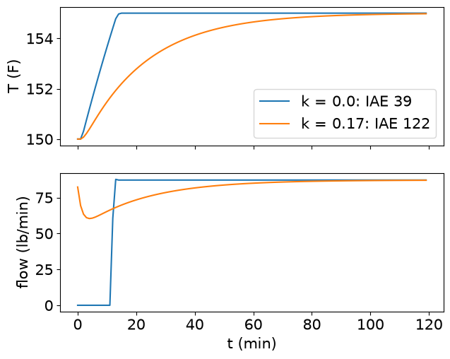

```python
fig, (a1, a2) = plt.subplots(2, 1, figsize=(7, 5.6), sharex=True)
for k in [0.0, 0.17]:
    y, M = qdmc(s1, s1, 60, 2, k)
    a1.plot(150 + y, label=f"k = {k}: IAE {np.abs(5 - y).sum():.0f}")
    a2.plot(108.8 + M)
a1.set(ylabel="T (F)"); a1.legend()
a2.set(xlabel="t (min)", ylabel="flow (lb/min)"); plt.show()
```

**Code walkthrough.** k = 0: the flow drops straight to zero (the constraint) and stays there until the temperature is nearly at 155; tracking is fast, IAE 39. k = 0.17: the first move is only -26.5 lb/min, the flow never goes below about 60, and the temperature approaches 155 more slowly (IAE 122). With a perfect model, suppression only costs speed...

### Build on it -- ...but the model is never perfect

- Plant gain 50% higher, dead time 5 min; same two controllers

```python
sp_bad = fopdt(np.arange(400.0), 1.5 * p[0], p[1], 5.0)
for k in [0.0, 0.17]:
    y, M = qdmc(s1, sp_bad, 60, 2, k)
    print(f"k = {k}: peak {150 + y.max():.2f} F, "
          f"IAE {np.abs(5 - y).sum():.0f}")
```

[output not shown]

**Code walkthrough.** Same controllers; the plant is now more sensitive and slower to respond than the model. k = 0: peak 157.58 F and a sustained oscillation (IAE 322). k = 0.17: peak 155.0 F, IAE 82 -- better than with the perfect model, because the extra plant gain speeds up the cautious controller. Move suppression buys robustness to model error, Cecil's reason for using it.

### Code 4/4 -- the same problem in GEKKO

- Model as an ODE, flow bounds built in, moves penalized (`DCOST`)
- Dead time (1.35 min against $\tau = 55$ min) neglected here

```python
m = GEKKO(remote=False); m.time = np.linspace(0, 60, 61)
Mv = m.MV(value=0, lb=-108.8, ub=91.2); Mv.STATUS = 1; Mv.DCOST = 0.3
Cv = m.CV(value=0); Cv.STATUS = 1; Cv.SP = 5; Cv.TR_INIT = 0
m.Equation(p[1] * Cv.dt() == -Cv + p[0] * Mv)   # FOPDT, no dead time
m.options.IMODE = 6; m.options.CV_TYPE = 2       # MPC, squared error
m.solve(disp=False)
T = 150 + np.array(list(Cv.value))
print("planned:", np.round(Mv.value[1:5], 1), "T(10), T(60):",
      T[[10, 60]].round(2))
```

```
planned: [-38.3 -64.7 -82.  -92.7] T(10), T(60): [153.25 154.96]
```

**Code walkthrough.** GEKKO builds and solves the optimization: `MV` is the manipulated variable with bounds, `STATUS = 1` lets the optimizer move it, `DCOST` penalizes each move (like k); `CV` is the controlled variable with set point 5; the FOPDT is an ODE in `Cv.dt()`. IMODE 6 is MPC; CV_TYPE 2 squares the error. `remote=False` solves on this machine. Planned flow changes (from 108.8) -38.3, -64.7, -82.0, -92.7: a gradual descent toward the lower bound; T reaches 153.25 F at 10 min, 154.96 at 60. Constraints are part of the problem, not clipped after.

### Your Turn (6 min)

1. By hand: at steady state, how much must the cooling flow change for +5 F? Compare with the sum of the two QDMC moves of Part B, $-95.8 + 75.1$.
2. Read the code: in `qdmc`, what would happen without the term `cp[i] - cm[i]`?

(1) 5/(-0.225) = -22.2 lb/min; the two moves sum to -20.7: close, and closer as R grows (Cecil). (2) No model-error feedback: the controller would act on the model alone. With a mismatched plant (or a disturbance) it would settle with an offset -- the term is MPC's integral action.

### Check -- poll

In GEKKO, raising `DCOST` from 0.3 to 30 would make the first planned flow change:

**A)** larger **B)** smaller **C)** unchanged, only later moves change

B: a much smaller first change than -38.3 lb/min. DCOST penalizes every move, the first included; the controller spreads the change over time and reaches the set point more slowly.

## Part D

### The Model Inside MPC, Identified from Data

(Cecil, Ch. 8, Sec. 8.3)

### Introduce -- a short, noisy plant test

- Cecil: the step-response coefficients can be fitted by **least squares** to any test data (finite impulse response, FIR).
- 60 impulse coefficients at $\Delta t = 5$ min; only 150 samples of a random +/-10 lb/min test; 0.1 F noise and 0.1 F resolution.
- Plain least squares fits the noise. **Ridge regression** (Lecture 10's ML tools, plus a penalty) shrinks the coefficients.
- Question: which model makes the better controller?

### Derive 1/1 -- FIR regression and its penalty

$c_k = \sum_{j=1}^{60} g_j\,m_{k-j}$: linear in $g$:

Least squares: $\min \|c - Xg\|^2$. Ridge: $\min \|c - Xg\|^2 + \alpha\|g\|^2$ -- the same form as move suppression, now on the model. `RidgeCV` picks $\alpha$ by cross-validation.

### Code 1/3 -- the test data and the regressors

- Column $j$ of $X$ is the input delayed by $j$ samples

```python
rng = np.random.default_rng(3)
n, N, dt5 = 150, 60, 5.0
m_test = np.repeat(rng.choice([-10.0, 10.0], n // 6 + 1), 6)[:n]
g_true = np.diff(fopdt(dt5 * np.arange(N + 1), *p))
c_meas = np.convolve(m_test, np.r_[0, g_true])[:n]
c_meas = np.round(c_meas + 0.1 * rng.standard_normal(n), 1)
X = np.column_stack([np.r_[np.zeros(j), m_test[:n - j]]
                     for j in range(1, N + 1)])
print(X.shape, c_meas[:5])
```

```
(150, 60) [-0.1 -0.3 -0.4 -0.5 -0.7]
```

**Code walkthrough.** The input holds each random +/-10 for 6 samples (30 min). `g_true` is the true impulse response (the fitted reactor at 5-min spacing); `np.convolve` applies the FIR sum; noise is added and the result rounded to 0.1 F like the real thermometer. `np.r_` concatenates; column j of X is the input delayed j samples, so X g is the FIR prediction. 150 rows, 60 unknowns.

### Code 2/3 -- least squares versus ridge

- Two scikit-learn regressors; cumulative sum turns $g$ into $s$

```python
fits = {"least squares": LinearRegression(fit_intercept=False),
        "ridge": RidgeCV(alphas=np.logspace(-2, 5, 30),
                         fit_intercept=False)}
s_id = {}
for name, mdl in fits.items():
    g_hat = mdl.fit(X, c_meas).coef_
    s_id[name] = np.r_[0, np.cumsum(g_hat)]
    print(f"{name}: gain {s_id[name][-1]:.3f}")
print("alpha chosen:", round(fits["ridge"].alpha_))
```

```
least squares: gain -0.230
ridge: gain -0.227
alpha chosen: 1172
```

**Code walkthrough.** `fit_intercept=False`: deviation variables, no offset term. `coef_` holds the 60 impulse coefficients; their running sum is the step-response model s(k). Both give a gain near the true -0.231 (-0.230 and -0.227), but the least-squares s(k) is jagged and the ridge one is smooth (the next plot). Cross-validation chose alpha = 1172.

### Code 3/3 -- put each model in the controller

- QDMC, $\Delta t = 5$ min, $R = 12$, $L = 2$, $k = 0$; true plant

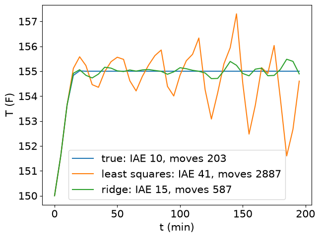

```python
s_plant = fopdt(dt5 * np.arange(400), *p)
fig, ax = plt.subplots(figsize=(7, 5.25))
for name, sm in [("true", s_plant), *s_id.items()]:
    sm = np.r_[sm, np.full(400 - len(sm), sm[-1])][:400]
    y, M = qdmc(sm, s_plant, 12, 2, 0.0, n=40)
    tv = np.abs(np.diff(np.r_[0, M])).sum()
    ax.plot(dt5 * np.arange(40), 150 + y,
            label=f"{name}: IAE {np.abs(5-y).sum():.0f}, "
                  f"moves {tv:.0f}")
ax.set(xlabel="t (min)", ylabel="T (F)"); ax.legend(); plt.show()
```

**Code walkthrough.** Each identified s(k) is padded with its final value to the length `qdmc` needs, then used as the controller's model against the true plant. "moves" is the total variation, the sum of |change in flow|: how hard the valve works. True model: IAE 10, moves 203. Least squares: IAE 41, moves 2887, and the temperature swings grow -- the noise in s(k) becomes valve thrashing. Ridge: IAE 15, moves 587. Regularizing the model did what smoothing did for Cecil.

### Your Turn (6 min)

Read the code: what does each print?

```
print(np.r_[0, np.cumsum([1.0, 2.0, 3.0])])
print(np.convolve([1.0, 0.0, 0.0], [0.0, 0.5, 0.3])[:3])
```

Which line turns an impulse response into a step response?

[0. 1. 3. 6.] and [0. 0.5 0.3]. The first: s(k) is the running sum of g(k). The second shows a unit pulse at k = 0 producing the impulse response itself.

### Check -- cold-call

Both identified models had nearly the right gain. Why did one make a much worse controller?

MPC uses the whole s(k) shape, especially the early coefficients that set the first moves; noise there is amplified by an aggressive controller (Cecil's quantization-noise example). A good model for control needs the right dynamics, not just the right gain: fit quality and control quality are different tests (Lectures 10-11).

### Wrap-up

**Derived, then coded:** the dead-time limit on PID and the Smith predictor; step and impulse response models and superposition; the dynamic matrix and QDMC; move suppression and constraints; GEKKO MPC; FIR identification by least squares and by ridge regression, judged inside the controller.

**Tools:** `deque` as a dead time, `toeplitz`, `np.linalg.solve`, receding-horizon loops, `GEKKO` (`MV`, `CV`, `IMODE = 6`), `RidgeCV`

**Course end:** from first-order lags to model predictive control.